# R Programming in Data Science: High Velocity Data

[figure not shown]

[figure not shown]

### Baseline Function

The R language tries to make programming as easy as possible, but at the cost of slower performance.

There is a long list of suggested strategies to realize substantial performance improvements.

Some of them are useful when working with high-velocity data and some are useful when working with high-volume data.

In this chapter, let’s implement some of the high-velocity strategies and see how they affect execution speed. To start, I’ve created a script that accesses the high velocity data we’ve been working with.

### if else

Sometimes you need to test in a loop.

In our starting script, the code adds a column with a calculated value. It does this by testing the value of one column and placing the result in the new column. This is done with a standard if…then…else test There are faster alternatives. Let’s look at how to optimize this.

### Avoid copying data

Earlier, we looked at the cost of appending data to an object. Let’s spend a brief moment looking at the efficiency of a pre-allocated data structure vs the efficiency of appending data.

### All optimizations

Finally, let’s wrap all of these optimizations together to see if we’ve made any cumulative difference.

### Run the benchmark

In the last video, we saw that our assumptions about code efficiency might not have been what we first assumed.

Microbenchmark is a package that provides a great way to quantify this. Let’s spend a brief amount of time exploring this function.

### The benchmarks as a table

```
Unit: milliseconds
             expr      min       lq     mean   median       uq      max
         original 77.24173 83.37286 99.48348 88.92902 95.78662 486.7613
           ifElse 76.40300 86.10969 95.59276 89.50062 93.67985 354.4321
           nocopy 53.97300 59.91338 67.03282 65.59302 69.90057 166.6594
 allOptimizations 57.26035 64.08932 71.65161 69.83494 75.52353 181.7420
 neval
   100
   100
   100
   100
```

### The benchmarks as a boxplot

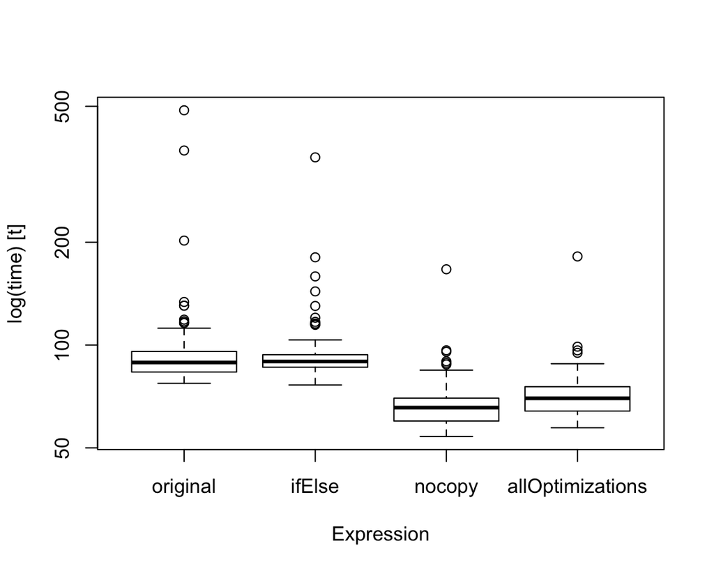

### The benchmarks as a plot

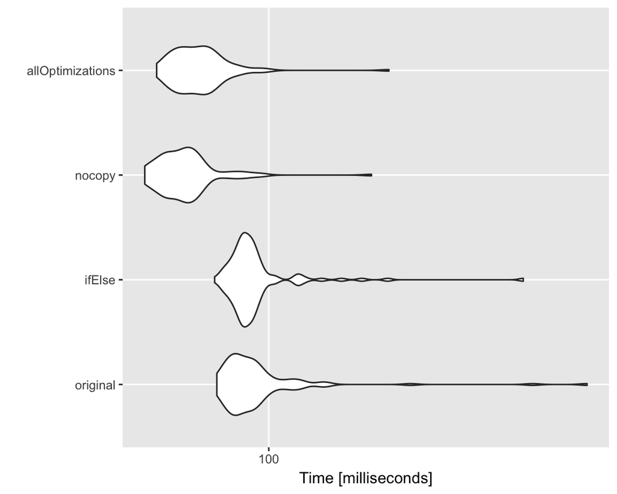

### remarks

MNR’s contact information [LinkedIn:](https://www.linkedin.com/in/markniemannross/) [Github:](https://github.com/mnr) [More Learning:](http://niemannross.com/link/mnratlil)